# Risk Factor Analysis

## Outcome Variable

**Outcome Variable:** sstunted

## Predictor Variables

**Intervention Variable:** mage

**Adjustment Set:**

unadjusted

## Stratifying Variables

The analysis was stratified on these variable(s):

- agecat
- studyid

The following strata were considered:

- agecat: 12 months, studyid: ki0047075b-MAL-ED
- agecat: 12 months, studyid: ki1000108-CMC-V-BCS-2002
- agecat: 12 months, studyid: ki1000108-IRC
- agecat: 12 months, studyid: ki1000109-EE
- agecat: 12 months, studyid: ki1000304b-SAS-FoodSuppl
- agecat: 12 months, studyid: ki1017093-NIH-Birth
- agecat: 12 months, studyid: ki1017093b-PROVIDE
- agecat: 12 months, studyid: ki1017093c-NIH-Crypto
- agecat: 12 months, studyid: ki1066203-TanzaniaChild2
- agecat: 12 months, studyid: ki1101329-Keneba
- agecat: 12 months, studyid: ki1112895-Guatemala BSC
- agecat: 12 months, studyid: ki1113344-GMS-Nepal
- agecat: 12 months, studyid: ki1126311-ZVITAMBO
- agecat: 12 months, studyid: ki1135781-COHORTS
- agecat: 12 months, studyid: ki1148112-LCNI-5
- agecat: 18 months, studyid: ki0047075b-MAL-ED
- agecat: 18 months, studyid: ki1000108-CMC-V-BCS-2002
- agecat: 18 months, studyid: ki1000108-IRC
- agecat: 18 months, studyid: ki1000109-EE
- agecat: 18 months, studyid: ki1000304b-SAS-FoodSuppl
- agecat: 18 months, studyid: ki1017093-NIH-Birth
- agecat: 18 months, studyid: ki1017093b-PROVIDE
- agecat: 18 months, studyid: ki1017093c-NIH-Crypto
- agecat: 18 months, studyid: ki1066203-TanzaniaChild2
- agecat: 18 months, studyid: ki1101329-Keneba
- agecat: 18 months, studyid: ki1113344-GMS-Nepal
- agecat: 18 months, studyid: ki1126311-ZVITAMBO
- agecat: 18 months, studyid: ki1135781-COHORTS
- agecat: 18 months, studyid: ki1148112-LCNI-5
- agecat: 24 months, studyid: ki0047075b-MAL-ED
- agecat: 24 months, studyid: ki1000108-CMC-V-BCS-2002
- agecat: 24 months, studyid: ki1000108-IRC
- agecat: 24 months, studyid: ki1017093-NIH-Birth
- agecat: 24 months, studyid: ki1017093b-PROVIDE
- agecat: 24 months, studyid: ki1017093c-NIH-Crypto
- agecat: 24 months, studyid: ki1066203-TanzaniaChild2
- agecat: 24 months, studyid: ki1101329-Keneba
- agecat: 24 months, studyid: ki1113344-GMS-Nepal
- agecat: 24 months, studyid: ki1126311-ZVITAMBO
- agecat: 24 months, studyid: ki1135781-COHORTS
- agecat: 24 months, studyid: ki1148112-LCNI-5
- agecat: 3 months, studyid: ki0047075b-MAL-ED
- agecat: 3 months, studyid: ki1000108-CMC-V-BCS-2002
- agecat: 3 months, studyid: ki1000108-IRC
- agecat: 3 months, studyid: ki1000109-EE
- agecat: 3 months, studyid: ki1000304b-SAS-FoodSuppl
- agecat: 3 months, studyid: ki1017093-NIH-Birth
- agecat: 3 months, studyid: ki1017093b-PROVIDE
- agecat: 3 months, studyid: ki1017093c-NIH-Crypto
- agecat: 3 months, studyid: ki1066203-TanzaniaChild2
- agecat: 3 months, studyid: ki1101329-Keneba
- agecat: 3 months, studyid: ki1112895-Guatemala BSC
- agecat: 3 months, studyid: ki1113344-GMS-Nepal
- agecat: 3 months, studyid: ki1126311-ZVITAMBO
- agecat: 3 months, studyid: ki1135781-COHORTS
- agecat: 6 months, studyid: ki0047075b-MAL-ED
- agecat: 6 months, studyid: ki1000108-CMC-V-BCS-2002
- agecat: 6 months, studyid: ki1000108-IRC
- agecat: 6 months, studyid: ki1000109-EE
- agecat: 6 months, studyid: ki1000304b-SAS-FoodSuppl
- agecat: 6 months, studyid: ki1017093-NIH-Birth
- agecat: 6 months, studyid: ki1017093b-PROVIDE
- agecat: 6 months, studyid: ki1017093c-NIH-Crypto
- agecat: 6 months, studyid: ki1066203-TanzaniaChild2
- agecat: 6 months, studyid: ki1101329-Keneba
- agecat: 6 months, studyid: ki1112895-Guatemala BSC
- agecat: 6 months, studyid: ki1113344-GMS-Nepal
- agecat: 6 months, studyid: ki1126311-ZVITAMBO
- agecat: 6 months, studyid: ki1135781-COHORTS
- agecat: 6 months, studyid: ki1148112-LCNI-5
- agecat: 9 months, studyid: ki0047075b-MAL-ED
- agecat: 9 months, studyid: ki1000108-CMC-V-BCS-2002
- agecat: 9 months, studyid: ki1000108-IRC
- agecat: 9 months, studyid: ki1000109-EE
- agecat: 9 months, studyid: ki1000304b-SAS-FoodSuppl
- agecat: 9 months, studyid: ki1017093-NIH-Birth
- agecat: 9 months, studyid: ki1017093b-PROVIDE
- agecat: 9 months, studyid: ki1017093c-NIH-Crypto
- agecat: 9 months, studyid: ki1066203-TanzaniaChild2
- agecat: 9 months, studyid: ki1101329-Keneba
- agecat: 9 months, studyid: ki1112895-Guatemala BSC
- agecat: 9 months, studyid: ki1113344-GMS-Nepal
- agecat: 9 months, studyid: ki1126311-ZVITAMBO
- agecat: 9 months, studyid: ki1135781-COHORTS
- agecat: 9 months, studyid: ki1148112-LCNI-5
- agecat: Birth, studyid: ki0047075b-MAL-ED
- agecat: Birth, studyid: ki1000108-CMC-V-BCS-2002
- agecat: Birth, studyid: ki1000108-IRC
- agecat: Birth, studyid: ki1000109-EE
- agecat: Birth, studyid: ki1017093-NIH-Birth
- agecat: Birth, studyid: ki1017093c-NIH-Crypto
- agecat: Birth, studyid: ki1101329-Keneba
- agecat: Birth, studyid: ki1126311-ZVITAMBO
- agecat: Birth, studyid: ki1135781-COHORTS

### Dropped Strata

Some strata were dropped due to rare outcomes:

- agecat: Birth, studyid: ki1000108-CMC-V-BCS-2002
- agecat: Birth, studyid: ki1000108-IRC
- agecat: Birth, studyid: ki1000109-EE
- agecat: Birth, studyid: ki1017093-NIH-Birth
- agecat: Birth, studyid: ki1017093c-NIH-Crypto
- agecat: Birth, studyid: ki1101329-Keneba
- agecat: 3 months, studyid: ki1000108-CMC-V-BCS-2002
- agecat: 3 months, studyid: ki1000108-IRC
- agecat: 3 months, studyid: ki1000109-EE
- agecat: 3 months, studyid: ki1000304b-SAS-FoodSuppl
- agecat: 3 months, studyid: ki1017093b-PROVIDE
- agecat: 3 months, studyid: ki1017093c-NIH-Crypto
- agecat: 3 months, studyid: ki1066203-TanzaniaChild2
- agecat: 3 months, studyid: ki1112895-Guatemala BSC
- agecat: 3 months, studyid: ki1113344-GMS-Nepal
- agecat: 6 months, studyid: ki1000108-IRC
- agecat: 6 months, studyid: ki1000109-EE
- agecat: 6 months, studyid: ki1000304b-SAS-FoodSuppl
- agecat: 6 months, studyid: ki1017093b-PROVIDE
- agecat: 6 months, studyid: ki1017093c-NIH-Crypto
- agecat: 6 months, studyid: ki1066203-TanzaniaChild2
- agecat: 6 months, studyid: ki1112895-Guatemala BSC
- agecat: 6 months, studyid: ki1113344-GMS-Nepal
- agecat: 9 months, studyid: ki1000108-IRC
- agecat: 9 months, studyid: ki1000109-EE
- agecat: 9 months, studyid: ki1000304b-SAS-FoodSuppl
- agecat: 9 months, studyid: ki1017093b-PROVIDE
- agecat: 9 months, studyid: ki1066203-TanzaniaChild2
- agecat: 9 months, studyid: ki1112895-Guatemala BSC
- agecat: 9 months, studyid: ki1148112-LCNI-5
- agecat: 12 months, studyid: ki1000108-IRC
- agecat: 12 months, studyid: ki1000109-EE
- agecat: 12 months, studyid: ki1017093b-PROVIDE
- agecat: 12 months, studyid: ki1066203-TanzaniaChild2
- agecat: 12 months, studyid: ki1112895-Guatemala BSC
- agecat: 12 months, studyid: ki1148112-LCNI-5
- agecat: 18 months, studyid: ki1000108-IRC
- agecat: 18 months, studyid: ki1000109-EE
- agecat: 18 months, studyid: ki1017093b-PROVIDE
- agecat: 18 months, studyid: ki1066203-TanzaniaChild2
- agecat: 24 months, studyid: ki1000108-IRC
- agecat: 24 months, studyid: ki1017093b-PROVIDE
- agecat: 24 months, studyid: ki1017093c-NIH-Crypto
- agecat: 24 months, studyid: ki1066203-TanzaniaChild2
- agecat: 24 months, studyid: ki1126311-ZVITAMBO

## Methods Detail

We’re interested in the causal parameters $E[Y_a]$ for all values of $a \in \mathcal{A}$. These parameters represent the mean outcome if, possibly contrary to fact, we intervened to set all units to have $A=a$. Under the randomization and positivity assumptions, these are identified by the statistical parameters $\psi_a=E_W[E_{Y|A,W}(Y|A=a,W)]$. In addition, we’re interested in the mean of $Y$, $E[Y]$ under no intervention (the observed mean). We will estimate these parameters by using SuperLearner to fit the relevant likelihood factors – $E_{Y|A,W}(Y|A=a,W)$ and $p(A=a|W)$, and then updating our likelihood fit using a joint TMLE.

For unadjusted analyses ($W=\{\}$), initial likelihoods were estimated using Lrnr_glm to estimate the simple $E(Y|A)$ and Lrnr_mean to estimate $p(A)$. For adjusted analyses, a small library containing Lrnr_glmnet, Lrnr_xgboost, and Lrnr_mean was used.

Having estimated these parameters, we will then use the delta method to estimate relative risks and attributable risks relative to a prespecified baseline level of $A$.

# Results Detail

## Results Plots

[figure not shown]

[figure not shown]

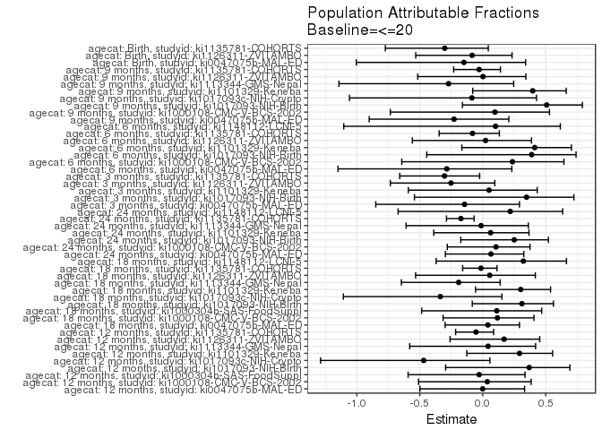

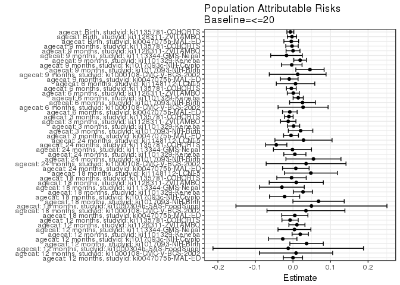

## Data Summary

| agecat | studyid | A | n | nA | nAY0 | nAY1 |
| --- | --- | --- | --- | --- | --- | --- |
| Birth | ki0047075b-MAL-ED | <=20 | 1498 | 340 | 328 | 12 |
| Birth | ki0047075b-MAL-ED | (20-24] | 1498 | 378 | 367 | 11 |
| Birth | ki0047075b-MAL-ED | (24-28] | 1498 | 399 | 384 | 15 |
| Birth | ki0047075b-MAL-ED | >28 | 1498 | 381 | 373 | 8 |
| Birth | ki1000108-CMC-V-BCS-2002 | <=20 | 90 | 20 | 17 | 3 |
| Birth | ki1000108-CMC-V-BCS-2002 | (20-24] | 90 | 33 | 33 | 0 |
| Birth | ki1000108-CMC-V-BCS-2002 | (24-28] | 90 | 29 | 29 | 0 |
| Birth | ki1000108-CMC-V-BCS-2002 | >28 | 90 | 8 | 8 | 0 |
| Birth | ki1000108-IRC | <=20 | 388 | 81 | 75 | 6 |
| Birth | ki1000108-IRC | (20-24] | 388 | 164 | 157 | 7 |
| Birth | ki1000108-IRC | (24-28] | 388 | 102 | 99 | 3 |
| Birth | ki1000108-IRC | >28 | 388 | 41 | 41 | 0 |
| Birth | ki1000109-EE | <=20 | 2 | 0 | 0 | 0 |
| Birth | ki1000109-EE | (20-24] | 2 | 0 | 0 | 0 |
| Birth | ki1000109-EE | (24-28] | 2 | 0 | 0 | 0 |
| Birth | ki1000109-EE | >28 | 2 | 2 | 2 | 0 |
| Birth | ki1000304b-SAS-FoodSuppl | <=20 | 0 | 0 | 0 | 0 |
| Birth | ki1000304b-SAS-FoodSuppl | (20-24] | 0 | 0 | 0 | 0 |
| Birth | ki1000304b-SAS-FoodSuppl | (24-28] | 0 | 0 | 0 | 0 |
| Birth | ki1000304b-SAS-FoodSuppl | >28 | 0 | 0 | 0 | 0 |
| Birth | ki1017093-NIH-Birth | <=20 | 28 | 9 | 9 | 0 |
| Birth | ki1017093-NIH-Birth | (20-24] | 28 | 7 | 7 | 0 |
| Birth | ki1017093-NIH-Birth | (24-28] | 28 | 5 | 5 | 0 |
| Birth | ki1017093-NIH-Birth | >28 | 28 | 7 | 7 | 0 |
| Birth | ki1017093b-PROVIDE | <=20 | 0 | 0 | 0 | 0 |
| Birth | ki1017093b-PROVIDE | (20-24] | 0 | 0 | 0 | 0 |
| Birth | ki1017093b-PROVIDE | (24-28] | 0 | 0 | 0 | 0 |
| Birth | ki1017093b-PROVIDE | >28 | 0 | 0 | 0 | 0 |
| Birth | ki1017093c-NIH-Crypto | <=20 | 27 | 10 | 9 | 1 |
| Birth | ki1017093c-NIH-Crypto | (20-24] | 27 | 6 | 6 | 0 |

[output cut: 390 more lines]

## Results Table

### Parameter: TSM

| agecat | studyid | intervention_level | baseline_level | estimate | ci_lower | ci_upper |
| --- | --- | --- | --- | --- | --- | --- |
| Birth | ki0047075b-MAL-ED | <=20 | NA | 0.0352941 | 0.0156740 | 0.0549143 |
| Birth | ki0047075b-MAL-ED | (20-24] | NA | 0.0291005 | 0.0121499 | 0.0460511 |
| Birth | ki0047075b-MAL-ED | (24-28] | NA | 0.0375940 | 0.0189240 | 0.0562640 |
| Birth | ki0047075b-MAL-ED | >28 | NA | 0.0209974 | 0.0065960 | 0.0353988 |
| Birth | ki1126311-ZVITAMBO | <=20 | NA | 0.0353075 | 0.0230982 | 0.0475169 |
| Birth | ki1126311-ZVITAMBO | (20-24] | NA | 0.0336283 | 0.0231160 | 0.0441406 |
| Birth | ki1126311-ZVITAMBO | (24-28] | NA | 0.0360481 | 0.0226963 | 0.0493998 |
| Birth | ki1126311-ZVITAMBO | >28 | NA | 0.0234604 | 0.0120990 | 0.0348218 |
| Birth | ki1135781-COHORTS | <=20 | NA | 0.0299539 | 0.0206943 | 0.0392135 |
| Birth | ki1135781-COHORTS | (20-24] | NA | 0.0227480 | 0.0165144 | 0.0289815 |
| Birth | ki1135781-COHORTS | (24-28] | NA | 0.0215497 | 0.0154553 | 0.0276442 |
| Birth | ki1135781-COHORTS | >28 | NA | 0.0208752 | 0.0152605 | 0.0264898 |
| 3 months | ki0047075b-MAL-ED | <=20 | NA | 0.0412371 | 0.0214467 | 0.0610275 |
| 3 months | ki0047075b-MAL-ED | (20-24] | NA | 0.0479616 | 0.0274464 | 0.0684769 |
| 3 months | ki0047075b-MAL-ED | (24-28] | NA | 0.0250522 | 0.0110526 | 0.0390518 |
| 3 months | ki0047075b-MAL-ED | >28 | NA | 0.0325203 | 0.0168425 | 0.0481982 |
| 3 months | ki1017093-NIH-Birth | <=20 | NA | 0.0378788 | 0.0052834 | 0.0704742 |
| 3 months | ki1017093-NIH-Birth | (20-24] | NA | 0.0349650 | 0.0048314 | 0.0650986 |
| 3 months | ki1017093-NIH-Birth | (24-28] | NA | 0.0828025 | 0.0396572 | 0.1259479 |
| 3 months | ki1017093-NIH-Birth | >28 | NA | 0.0735294 | 0.0296251 | 0.1174338 |
| 3 months | ki1101329-Keneba | <=20 | NA | 0.0314607 | 0.0152384 | 0.0476829 |
| 3 months | ki1101329-Keneba | (20-24] | NA | 0.0316027 | 0.0153084 | 0.0478970 |
| 3 months | ki1101329-Keneba | (24-28] | NA | 0.0234375 | 0.0083023 | 0.0385727 |
| 3 months | ki1101329-Keneba | >28 | NA | 0.0388027 | 0.0261965 | 0.0514088 |
| 3 months | ki1126311-ZVITAMBO | <=20 | NA | 0.0629630 | 0.0424717 | 0.0834542 |
| 3 months | ki1126311-ZVITAMBO | (20-24] | NA | 0.0479549 | 0.0322235 | 0.0636862 |
| 3 months | ki1126311-ZVITAMBO | (24-28] | NA | 0.0462428 | 0.0281710 | 0.0643146 |
| 3 months | ki1126311-ZVITAMBO | >28 | NA | 0.0440882 | 0.0260720 | 0.0621044 |
| 3 months | ki1135781-COHORTS | <=20 | NA | 0.0471910 | 0.0358156 | 0.0585664 |
| 3 months | ki1135781-COHORTS | (20-24] | NA | 0.0277405 | 0.0209315 | 0.0345495 |

[output cut: 166 more lines]

### Parameter: E(Y)

| agecat | studyid | intervention_level | baseline_level | estimate | ci_lower | ci_upper |
| --- | --- | --- | --- | --- | --- | --- |
| Birth | ki0047075b-MAL-ED | NA | NA | 0.0307076 | 0.0303792 | 0.0310361 |
| Birth | ki1126311-ZVITAMBO | NA | NA | 0.0325676 | 0.0324131 | 0.0327221 |
| Birth | ki1135781-COHORTS | NA | NA | 0.0230054 | 0.0229380 | 0.0230728 |
| 3 months | ki0047075b-MAL-ED | NA | NA | 0.0360360 | 0.0356324 | 0.0364396 |
| 3 months | ki1017093-NIH-Birth | NA | NA | 0.0580986 | 0.0563420 | 0.0598552 |
| 3 months | ki1101329-Keneba | NA | NA | 0.0331187 | 0.0328846 | 0.0333527 |
| 3 months | ki1126311-ZVITAMBO | NA | NA | 0.0502867 | 0.0499893 | 0.0505841 |
| 3 months | ki1135781-COHORTS | NA | NA | 0.0362007 | 0.0360572 | 0.0363442 |
| 6 months | ki0047075b-MAL-ED | NA | NA | 0.0295159 | 0.0292219 | 0.0298099 |
| 6 months | ki1000108-CMC-V-BCS-2002 | NA | NA | 0.1138211 | 0.1116240 | 0.1160183 |
| 6 months | ki1017093-NIH-Birth | NA | NA | 0.0654206 | 0.0640316 | 0.0668095 |
| 6 months | ki1101329-Keneba | NA | NA | 0.0336538 | 0.0331769 | 0.0341307 |
| 6 months | ki1126311-ZVITAMBO | NA | NA | 0.0351391 | 0.0350168 | 0.0352614 |
| 6 months | ki1135781-COHORTS | NA | NA | 0.0548539 | 0.0546824 | 0.0550254 |
| 6 months | ki1148112-LCNI-5 | NA | NA | 0.0670554 | 0.0663475 | 0.0677633 |
| 9 months | ki0047075b-MAL-ED | NA | NA | 0.0439560 | 0.0436535 | 0.0442586 |
| 9 months | ki1000108-CMC-V-BCS-2002 | NA | NA | 0.1284153 | 0.1273297 | 0.1295009 |
| 9 months | ki1017093-NIH-Birth | NA | NA | 0.0891089 | 0.0868801 | 0.0913377 |
| 9 months | ki1017093c-NIH-Crypto | NA | NA | 0.0396601 | 0.0391379 | 0.0401822 |
| 9 months | ki1101329-Keneba | NA | NA | 0.0476422 | 0.0470285 | 0.0482559 |
| 9 months | ki1113344-GMS-Nepal | NA | NA | 0.0635209 | 0.0625074 | 0.0645343 |
| 9 months | ki1126311-ZVITAMBO | NA | NA | 0.0443878 | 0.0441235 | 0.0446520 |
| 9 months | ki1135781-COHORTS | NA | NA | 0.0898228 | 0.0894524 | 0.0901931 |
| 12 months | ki0047075b-MAL-ED | NA | NA | 0.0631970 | 0.0631026 | 0.0632914 |
| 12 months | ki1000108-CMC-V-BCS-2002 | NA | NA | 0.2255435 | 0.2209709 | 0.2301161 |
| 12 months | ki1000304b-SAS-FoodSuppl | NA | NA | 0.4456522 | 0.4420002 | 0.4493041 |
| 12 months | ki1017093-NIH-Birth | NA | NA | 0.0981595 | 0.0960524 | 0.1002666 |
| 12 months | ki1017093c-NIH-Crypto | NA | NA | 0.0580737 | 0.0562377 | 0.0599096 |
| 12 months | ki1101329-Keneba | NA | NA | 0.0661499 | 0.0651643 | 0.0671354 |
| 12 months | ki1113344-GMS-Nepal | NA | NA | 0.0913978 | 0.0896964 | 0.0930993 |
| 12 months | ki1126311-ZVITAMBO | NA | NA | 0.0618375 | 0.0614402 | 0.0622347 |
| 12 months | ki1135781-COHORTS | NA | NA | 0.1442155 | 0.1437202 | 0.1447109 |
| 18 months | ki0047075b-MAL-ED | NA | NA | 0.1198187 | 0.1193605 | 0.1202768 |
| 18 months | ki1000108-CMC-V-BCS-2002 | NA | NA | 0.2953930 | 0.2914031 | 0.2993828 |
| 18 months | ki1000304b-SAS-FoodSuppl | NA | NA | 0.4404762 | 0.4262342 | 0.4547181 |
| 18 months | ki1017093-NIH-Birth | NA | NA | 0.2190889 | 0.2152132 | 0.2229646 |
| 18 months | ki1017093c-NIH-Crypto | NA | NA | 0.0662461 | 0.0643390 | 0.0681531 |
| 18 months | ki1101329-Keneba | NA | NA | 0.0884817 | 0.0875472 | 0.0894161 |
| 18 months | ki1113344-GMS-Nepal | NA | NA | 0.1545455 | 0.1527050 | 0.1563859 |
| 18 months | ki1126311-ZVITAMBO | NA | NA | 0.1576471 | 0.1549127 | 0.1603814 |
| 18 months | ki1135781-COHORTS | NA | NA | 0.2875683 | 0.2866678 | 0.2884688 |
| 18 months | ki1148112-LCNI-5 | NA | NA | 0.1476510 | 0.1441917 | 0.1511103 |
| 24 months | ki0047075b-MAL-ED | NA | NA | 0.1156691 | 0.1148670 | 0.1164713 |
| 24 months | ki1000108-CMC-V-BCS-2002 | NA | NA | 0.3306452 | 0.3275534 | 0.3337369 |
| 24 months | ki1017093-NIH-Birth | NA | NA | 0.2177986 | 0.2145089 | 0.2210883 |
| 24 months | ki1101329-Keneba | NA | NA | 0.0799300 | 0.0794305 | 0.0804295 |
| 24 months | ki1113344-GMS-Nepal | NA | NA | 0.1082164 | 0.1078742 | 0.1085586 |
| 24 months | ki1135781-COHORTS | NA | NA | 0.2575849 | 0.2568401 | 0.2583296 |
| 24 months | ki1148112-LCNI-5 | NA | NA | 0.1280000 | 0.1248630 | 0.1311370 |

### Parameter: RR

| agecat | studyid | intervention_level | baseline_level | estimate | ci_lower | ci_upper |
| --- | --- | --- | --- | --- | --- | --- |
| Birth | ki0047075b-MAL-ED | (20-24] | <=20 | 0.8245150 | 0.3685639 | 1.8445241 |
| Birth | ki0047075b-MAL-ED | (24-28] | <=20 | 1.0651629 | 0.5054527 | 2.2446649 |
| Birth | ki0047075b-MAL-ED | >28 | <=20 | 0.5949256 | 0.2460600 | 1.4384152 |
| Birth | ki1126311-ZVITAMBO | (20-24] | <=20 | 0.9524408 | 0.5975728 | 1.5180467 |
| Birth | ki1126311-ZVITAMBO | (24-28] | <=20 | 1.0209742 | 0.6151049 | 1.6946514 |
| Birth | ki1126311-ZVITAMBO | >28 | <=20 | 0.6644594 | 0.3664665 | 1.2047657 |
| Birth | ki1135781-COHORTS | (20-24] | <=20 | 0.7594317 | 0.5024375 | 1.1478770 |
| Birth | ki1135781-COHORTS | (24-28] | <=20 | 0.7194300 | 0.4731830 | 1.0938255 |
| Birth | ki1135781-COHORTS | >28 | <=20 | 0.6969089 | 0.4626160 | 1.0498600 |
| 3 months | ki0047075b-MAL-ED | (20-24] | <=20 | 1.1630695 | 0.6115191 | 2.2120825 |
| 3 months | ki0047075b-MAL-ED | (24-28] | <=20 | 0.6075157 | 0.2908377 | 1.2690075 |
| 3 months | ki0047075b-MAL-ED | >28 | <=20 | 0.7886179 | 0.3994290 | 1.5570180 |
| 3 months | ki1017093-NIH-Birth | (20-24] | <=20 | 0.9230769 | 0.2730988 | 3.1200106 |
| 3 months | ki1017093-NIH-Birth | (24-28] | <=20 | 2.1859873 | 0.7993833 | 5.9777837 |
| 3 months | ki1017093-NIH-Birth | >28 | <=20 | 1.9411765 | 0.6810677 | 5.5327332 |
| 3 months | ki1101329-Keneba | (20-24] | <=20 | 1.0045147 | 0.4844761 | 2.0827646 |
| 3 months | ki1101329-Keneba | (24-28] | <=20 | 0.7449777 | 0.3260265 | 1.7022902 |
| 3 months | ki1101329-Keneba | >28 | <=20 | 1.2333703 | 0.6705236 | 2.2686781 |
| 3 months | ki1126311-ZVITAMBO | (20-24] | <=20 | 0.7616361 | 0.4798029 | 1.2090164 |
| 3 months | ki1126311-ZVITAMBO | (24-28] | <=20 | 0.7344441 | 0.4416615 | 1.2213156 |
| 3 months | ki1126311-ZVITAMBO | >28 | <=20 | 0.7002240 | 0.4152987 | 1.1806289 |
| 3 months | ki1135781-COHORTS | (20-24] | <=20 | 0.5878342 | 0.4167228 | 0.8292062 |
| 3 months | ki1135781-COHORTS | (24-28] | <=20 | 0.7129155 | 0.5140507 | 0.9887129 |
| 3 months | ki1135781-COHORTS | >28 | <=20 | 0.8506212 | 0.6257500 | 1.1563029 |
| 6 months | ki0047075b-MAL-ED | (20-24] | <=20 | 0.7358593 | 0.3383183 | 1.6005311 |
| 6 months | ki0047075b-MAL-ED | (24-28] | <=20 | 0.8613445 | 0.4211319 | 1.7617152 |
| 6 months | ki0047075b-MAL-ED | >28 | <=20 | 0.5584140 | 0.2508544 | 1.2430566 |
| 6 months | ki1000108-CMC-V-BCS-2002 | (20-24] | <=20 | 1.3892617 | 0.5762745 | 3.3491823 |
| 6 months | ki1000108-CMC-V-BCS-2002 | (24-28] | <=20 | 1.1500000 | 0.4377668 | 3.0210146 |
| 6 months | ki1000108-CMC-V-BCS-2002 | >28 | <=20 | 1.8039216 | 0.6662513 | 4.8842425 |

[output cut: 117 more lines]

### Parameter: PAR

| agecat | studyid | intervention_level | baseline_level | estimate | ci_lower | ci_upper |
| --- | --- | --- | --- | --- | --- | --- |
| Birth | ki0047075b-MAL-ED | <=20 | NA | -0.0045865 | -0.0242094 | 0.0150364 |
| Birth | ki1126311-ZVITAMBO | <=20 | NA | -0.0027399 | -0.0149502 | 0.0094704 |
| Birth | ki1135781-COHORTS | <=20 | NA | -0.0069485 | -0.0162084 | 0.0023113 |
| 3 months | ki0047075b-MAL-ED | <=20 | NA | -0.0052011 | -0.0249956 | 0.0145934 |
| 3 months | ki1017093-NIH-Birth | <=20 | NA | 0.0202198 | -0.0124229 | 0.0528625 |
| 3 months | ki1101329-Keneba | <=20 | NA | 0.0016580 | -0.0145659 | 0.0178819 |
| 3 months | ki1126311-ZVITAMBO | <=20 | NA | -0.0126762 | -0.0331696 | 0.0078171 |
| 3 months | ki1135781-COHORTS | <=20 | NA | -0.0109903 | -0.0223666 | 0.0003860 |
| 6 months | ki0047075b-MAL-ED | <=20 | NA | -0.0084244 | -0.0279258 | 0.0110769 |
| 6 months | ki1000108-CMC-V-BCS-2002 | <=20 | NA | 0.0268646 | -0.0397464 | 0.0934756 |
| 6 months | ki1017093-NIH-Birth | <=20 | NA | 0.0254206 | -0.0089922 | 0.0598333 |
| 6 months | ki1101329-Keneba | <=20 | NA | 0.0139008 | 0.0003370 | 0.0274645 |
| 6 months | ki1126311-ZVITAMBO | <=20 | NA | 0.0007957 | -0.0152515 | 0.0168428 |
| 6 months | ki1135781-COHORTS | <=20 | NA | -0.0044346 | -0.0174508 | 0.0085815 |
| 6 months | ki1148112-LCNI-5 | <=20 | NA | 0.0068144 | -0.0444527 | 0.0580815 |
| 9 months | ki0047075b-MAL-ED | <=20 | NA | -0.0100212 | -0.0336370 | 0.0135945 |
| 9 months | ki1000108-CMC-V-BCS-2002 | <=20 | NA | 0.0124733 | -0.0631792 | 0.0881258 |
| 9 months | ki1017093-NIH-Birth | <=20 | NA | 0.0452493 | 0.0075546 | 0.0829439 |
| 9 months | ki1017093c-NIH-Crypto | <=20 | NA | -0.0034021 | -0.0309477 | 0.0241434 |
| 9 months | ki1101329-Keneba | <=20 | NA | 0.0189216 | 0.0021793 | 0.0356639 |
| 9 months | ki1113344-GMS-Nepal | <=20 | NA | -0.0172245 | -0.0593584 | 0.0249095 |
| 9 months | ki1126311-ZVITAMBO | <=20 | NA | 0.0000840 | -0.0184468 | 0.0186148 |
| 9 months | ki1135781-COHORTS | <=20 | NA | -0.0025639 | -0.0191687 | 0.0140409 |
| 12 months | ki0047075b-MAL-ED | <=20 | NA | -0.0000214 | -0.0255976 | 0.0255549 |
| 12 months | ki1000108-CMC-V-BCS-2002 | <=20 | NA | 0.0081522 | -0.0894109 | 0.1057152 |
| 12 months | ki1000304b-SAS-FoodSuppl | <=20 | NA | -0.0126812 | -0.2131489 | 0.1877866 |
| 12 months | ki1017093-NIH-Birth | <=20 | NA | 0.0362126 | -0.0083287 | 0.0807540 |
| 12 months | ki1017093c-NIH-Crypto | <=20 | NA | -0.0272344 | -0.0649969 | 0.0105281 |
| 12 months | ki1101329-Keneba | <=20 | NA | 0.0193179 | -0.0024446 | 0.0410804 |
| 12 months | ki1113344-GMS-Nepal | <=20 | NA | 0.0038978 | -0.0399578 | 0.0477535 |
| 12 months | ki1126311-ZVITAMBO | <=20 | NA | 0.0104927 | -0.0109062 | 0.0318916 |
| 12 months | ki1135781-COHORTS | <=20 | NA | -0.0077313 | -0.0294201 | 0.0139575 |
| 18 months | ki0047075b-MAL-ED | <=20 | NA | 0.0049118 | -0.0299352 | 0.0397589 |
| 18 months | ki1000108-CMC-V-BCS-2002 | <=20 | NA | 0.0345234 | -0.0693026 | 0.1383494 |
| 18 months | ki1000304b-SAS-FoodSuppl | <=20 | NA | 0.0491718 | -0.1519844 | 0.2503281 |
| 18 months | ki1017093-NIH-Birth | <=20 | NA | 0.0681455 | -0.0001892 | 0.1364803 |
| 18 months | ki1017093c-NIH-Crypto | <=20 | NA | -0.0222956 | -0.0625553 | 0.0179641 |
| 18 months | ki1101329-Keneba | <=20 | NA | 0.0267170 | 0.0011053 | 0.0523286 |
| 18 months | ki1113344-GMS-Nepal | <=20 | NA | -0.0295036 | -0.0890775 | 0.0300702 |
| 18 months | ki1126311-ZVITAMBO | <=20 | NA | 0.0087109 | -0.0633981 | 0.0808199 |
| 18 months | ki1135781-COHORTS | <=20 | NA | -0.0039375 | -0.0430904 | 0.0352154 |
| 18 months | ki1148112-LCNI-5 | <=20 | NA | 0.0476510 | -0.0228303 | 0.1181323 |
| 24 months | ki0047075b-MAL-ED | <=20 | NA | 0.0075610 | -0.0278342 | 0.0429563 |
| 24 months | ki1000108-CMC-V-BCS-2002 | <=20 | NA | 0.0348705 | -0.0714760 | 0.1412170 |
| 24 months | ki1017093-NIH-Birth | <=20 | NA | 0.0545333 | -0.0188036 | 0.1278702 |
| 24 months | ki1101329-Keneba | <=20 | NA | 0.0050114 | -0.0244499 | 0.0344728 |
| 24 months | ki1113344-GMS-Nepal | <=20 | NA | -0.0013726 | -0.0520946 | 0.0493493 |
| 24 months | ki1135781-COHORTS | <=20 | NA | -0.0445805 | -0.0728282 | -0.0163328 |
| 24 months | ki1148112-LCNI-5 | <=20 | NA | 0.0280000 | -0.0481260 | 0.1041260 |

### Parameter: PAF

| agecat | studyid | intervention_level | baseline_level | estimate | ci_lower | ci_upper |
| --- | --- | --- | --- | --- | --- | --- |
| Birth | ki0047075b-MAL-ED | <=20 | NA | -0.1493606 | -1.0041356 | 0.3408481 |
| Birth | ki1126311-ZVITAMBO | <=20 | NA | -0.0841299 | -0.5320553 | 0.2328360 |
| Birth | ki1135781-COHORTS | <=20 | NA | -0.3020394 | -0.7737108 | 0.0442035 |
| 3 months | ki0047075b-MAL-ED | <=20 | NA | -0.1443299 | -0.8494102 | 0.2919413 |
| 3 months | ki1017093-NIH-Birth | <=20 | NA | 0.3480257 | -0.5423391 | 0.7243988 |
| 3 months | ki1101329-Keneba | <=20 | NA | 0.0500624 | -0.5909394 | 0.4327997 |
| 3 months | ki1126311-ZVITAMBO | <=20 | NA | -0.2520793 | -0.7337873 | 0.0957931 |
| 3 months | ki1135781-COHORTS | <=20 | NA | -0.3035933 | -0.6589865 | -0.0243335 |
| 6 months | ki0047075b-MAL-ED | <=20 | NA | -0.2854201 | -1.1492589 | 0.2312212 |
| 6 months | ki1000108-CMC-V-BCS-2002 | <=20 | NA | 0.2360248 | -0.6431795 | 0.6447996 |
| 6 months | ki1017093-NIH-Birth | <=20 | NA | 0.3885714 | -0.4447293 | 0.7412353 |
| 6 months | ki1101329-Keneba | <=20 | NA | 0.4130511 | -0.1659865 | 0.7045343 |
| 6 months | ki1126311-ZVITAMBO | <=20 | NA | 0.0226431 | -0.5594772 | 0.3874700 |
| 6 months | ki1135781-COHORTS | <=20 | NA | -0.0808448 | -0.3461981 | 0.1322040 |
| 6 months | ki1148112-LCNI-5 | <=20 | NA | 0.1016239 | -1.1040237 | 0.6164113 |
| 9 months | ki0047075b-MAL-ED | <=20 | NA | -0.2279830 | -0.9019954 | 0.2071789 |
| 9 months | ki1000108-CMC-V-BCS-2002 | <=20 | NA | 0.0971323 | -0.7337922 | 0.5298340 |
| 9 months | ki1017093-NIH-Birth | <=20 | NA | 0.5077973 | -0.1611778 | 0.7913639 |
| 9 months | ki1017093c-NIH-Crypto | <=20 | NA | -0.0857826 | -1.0585245 | 0.4272966 |
| 9 months | ki1101329-Keneba | <=20 | NA | 0.3971599 | -0.0795929 | 0.6633767 |
| 9 months | ki1113344-GMS-Nepal | <=20 | NA | -0.2711624 | -1.1422082 | 0.2457065 |
| 9 months | ki1126311-ZVITAMBO | <=20 | NA | 0.0018915 | -0.5164519 | 0.3430582 |
| 9 months | ki1135781-COHORTS | <=20 | NA | -0.0285438 | -0.2310629 | 0.1406594 |
| 12 months | ki0047075b-MAL-ED | <=20 | NA | -0.0003381 | -0.4991643 | 0.3325106 |
| 12 months | ki1000108-CMC-V-BCS-2002 | <=20 | NA | 0.0361446 | -0.5097454 | 0.3846530 |
| 12 months | ki1000304b-SAS-FoodSuppl | <=20 | NA | -0.0284553 | -0.5927249 | 0.3359052 |
| 12 months | ki1017093-NIH-Birth | <=20 | NA | 0.3689159 | -0.2946291 | 0.6923697 |
| 12 months | ki1017093c-NIH-Crypto | <=20 | NA | -0.4689631 | -1.2883311 | 0.0570190 |
| 12 months | ki1101329-Keneba | <=20 | NA | 0.2920325 | -0.1264808 | 0.5550586 |
| 12 months | ki1113344-GMS-Nepal | <=20 | NA | 0.0426471 | -0.5802646 | 0.4200182 |
| 12 months | ki1126311-ZVITAMBO | <=20 | NA | 0.1696821 | -0.2596073 | 0.4526645 |
| 12 months | ki1135781-COHORTS | <=20 | NA | -0.0536093 | -0.2152688 | 0.0865457 |
| 18 months | ki0047075b-MAL-ED | <=20 | NA | 0.0409938 | -0.2987516 | 0.2918639 |
| 18 months | ki1000108-CMC-V-BCS-2002 | <=20 | NA | 0.1168728 | -0.3147531 | 0.4067983 |
| 18 months | ki1000304b-SAS-FoodSuppl | <=20 | NA | 0.1116334 | -0.4850129 | 0.4685600 |
| 18 months | ki1017093-NIH-Birth | <=20 | NA | 0.3110405 | -0.0830296 | 0.5617247 |
| 18 months | ki1017093c-NIH-Crypto | <=20 | NA | -0.3365575 | -1.1068539 | 0.1521073 |
| 18 months | ki1101329-Keneba | <=20 | NA | 0.3019492 | -0.0566040 | 0.5388292 |
| 18 months | ki1113344-GMS-Nepal | <=20 | NA | -0.1909058 | -0.6461898 | 0.1384610 |
| 18 months | ki1126311-ZVITAMBO | <=20 | NA | 0.0552556 | -0.5330849 | 0.4178131 |
| 18 months | ki1135781-COHORTS | <=20 | NA | -0.0136923 | -0.1594121 | 0.1137127 |
| 18 months | ki1148112-LCNI-5 | <=20 | NA | 0.3227273 | -0.3698102 | 0.6651373 |
| 24 months | ki0047075b-MAL-ED | <=20 | NA | 0.0653677 | -0.2966622 | 0.3263183 |
| 24 months | ki1000108-CMC-V-BCS-2002 | <=20 | NA | 0.1054620 | -0.2815551 | 0.3756038 |
| 24 months | ki1017093-NIH-Birth | <=20 | NA | 0.2503840 | -0.1744455 | 0.5215409 |
| 24 months | ki1101329-Keneba | <=20 | NA | 0.0626976 | -0.3888678 | 0.3674447 |
| 24 months | ki1113344-GMS-Nepal | <=20 | NA | -0.0126839 | -0.6087255 | 0.3625210 |
| 24 months | ki1135781-COHORTS | <=20 | NA | -0.1730711 | -0.2880400 | -0.0683641 |
| 24 months | ki1148112-LCNI-5 | <=20 | NA | 0.2187500 | -0.6722135 | 0.6350038 |